# Predicting High-Yield Credit Spread Changes: A Comparative ML Analysis

## Overview

This project investigates the macroeconomic drivers of U.S. high-yield (HY) credit spread movements using LASSO regression and XGBoost. We model both **monthly** and **daily** frequency data, applying rigorous stationarity transformations and chronological train-test splits appropriate for time series data.

**Target variable:** Change in the ICE BofA U.S. High Yield Index Option-Adjusted Spread (BAMLH0A0HYM2)

**Features (macro drivers):**

- VIX (market fear/volatility)
- Bloomberg Financial Conditions Index
- S&P 500 returns
- Yield curve slope (10Y-2Y)
- Inflation expectations (10Y breakeven)
- Industrial production
- 2-year Treasury yield

## Setup

```python
# Core Data Science & Math Libraries
import numpy as np
import pandas as pd
import scipy.stats as stats
import matplotlib.pyplot as plt
import seaborn as sns
from sklearn.metrics import mean_absolute_error, mean_squared_error, r2_score

# Visualization
import matplotlib.pyplot as plt

# Machine Learning - Third Party
import xgboost as xgb

# Scikit-Learn - Preprocessing & Pipeline
from sklearn.base import clone
from sklearn.compose import ColumnTransformer
from sklearn.pipeline import Pipeline
from sklearn.preprocessing import FunctionTransformer, OneHotEncoder, StandardScaler

# Scikit-Learn - Model Selection
from sklearn.model_selection import GridSearchCV, cross_val_score, train_test_split
from sklearn.metrics import mean_absolute_error, mean_squared_error, r2_score

# Scikit-Learn - Models
from sklearn.linear_model import Lasso
from sklearn.tree import DecisionTreeRegressor, plot_tree

# Scikit-Learn - Metrics
from sklearn.metrics import mean_squared_error, r2_score, root_mean_squared_error
```

## 1. Data Import

We source all data from FRED (Federal Reserve Economic Data) and Bloomberg. Each series is loaded as a separate CSV and later merged on a common date index. The dataset covers daily observations spanning multiple economic cycles.

## Importing Data

```python
#fear factors:
vix = pd.read_csv("VIXCLS.csv")
FinCondn = pd.read_csv("tt_bfcius.csv") #•	Bloomberg Financial Conditions Index
spy = pd.read_csv("snp500.csv")

#Credit spread data:
USHY = pd.read_csv("BAMLH0A0HYM2.csv") #High Yield Index (It is reffered to as USHY)


#Macroeconomic Conditions
yeildslope = pd.read_csv("T10Y2Y.csv")
infexpect = pd.read_csv("T10YIE.csv")
indpro = pd.read_csv("INDPRO.csv")
yeild_2yr = pd.read_csv("DGS2.csv")
```

## 2. Data Cleaning and Merging

```python
# 1. Define a function that cleans each dataframe individually
def prepare_df(df, date_col, target_col):
    df = df.copy()
    # Ensure column is datetime
    df[date_col] = pd.to_datetime(df[date_col])
    # Rename to standard names
    df = df.rename(columns={date_col: 'date', target_col: target_col})
    return df[['date', target_col]]

# 2. Prepare each source
vix_c = prepare_df(vix, 'observation_date', 'VIXCLS')
fin_c = prepare_df(FinCondn, 'Date', 'PX_LAST')
spy_c = prepare_df(spy, 'Date', 'Close')
ushy_c = prepare_df(USHY, 'observation_date', 'BAMLH0A0HYM2')
yield_c = prepare_df(yeildslope, 'observation_date', 'T10Y2Y')
inf_c = prepare_df(infexpect, 'observation_date', 'T10YIE')
ind_c = prepare_df(indpro, 'observation_date', 'INDPRO')
dgs_c = prepare_df(yeild_2yr, 'observation_date', 'DGS2')

# 3. List of dataframes to merge
dfs = [ushy_c, vix_c, fin_c, spy_c, yield_c, inf_c, ind_c, dgs_c]

# 4. Merge everything using a loop
from functools import reduce
master_df = reduce(lambda left, right: pd.merge(left, right, on='date', how='outer'), dfs)

# 5. Sort and Forward Fill
master_df = master_df.sort_values('date').ffill()

# Rename the columns to intuitive names for the report
rename_dict = {
    'BAMLH0A0HYM2': 'HY_Spread',
    'VIXCLS': 'VIX',
    'PX_LAST': 'Fin_Cond',
    'Close': 'SPY',
    'T10Y2Y': 'Yield_Slope',
    'T10YIE': 'Inf_Expect',
    'INDPRO': 'Industrial_Prod',
    'DGS2': '2Y_Treasury'
}

master_df = master_df.rename(columns=rename_dict)

# Verification
print("Updated Columns:", master_df.columns.tolist())
```

```
Updated Columns: ['date', 'HY_Spread', 'VIX', 'Fin_Cond', 'SPY', 'Yield_Slope', 'Inf_Expect', 'Industrial_Prod', '2Y_Treasury']
```

## 3. Exploratory Data Analysis

Before modelling, we inspect the raw distributions of each variable. Most financial time series are non-stationary in levels (they exhibit trends or changing variance), motivating the stationarity transformations applied in the next step.

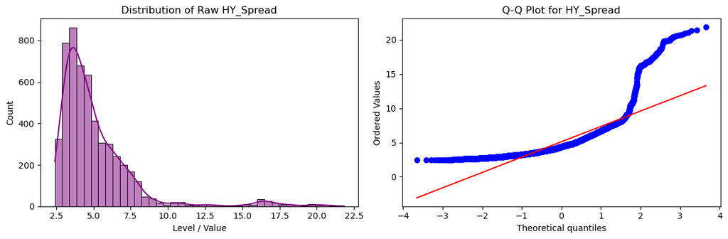

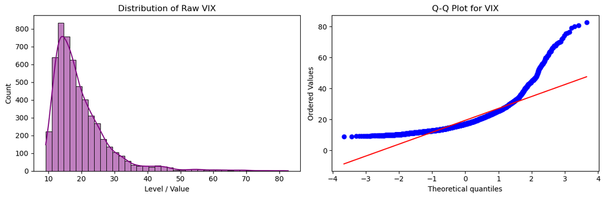

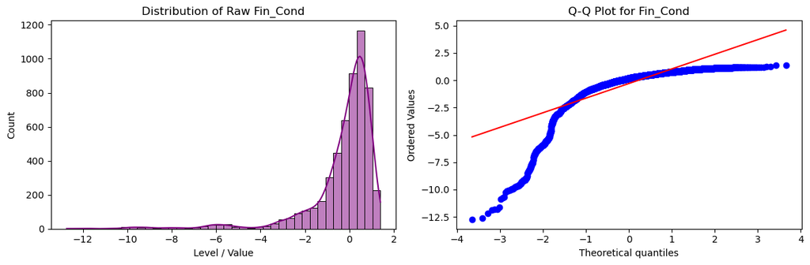

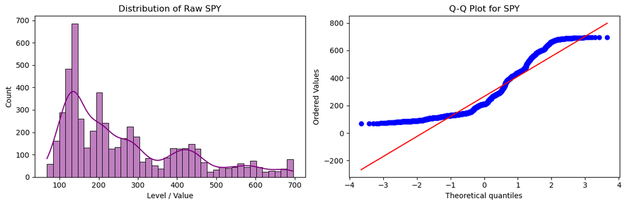

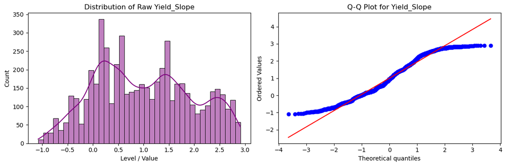

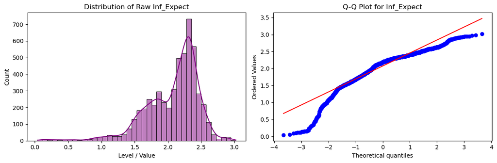

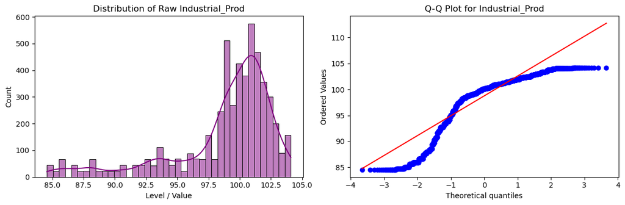

```python
# checking the distributions of our data


# Define the raw columns you want to inspect before transformation
raw_columns = ['HY_Spread', 'VIX','Fin_Cond', 'SPY', 'Yield_Slope', 'Inf_Expect', 'Industrial_Prod', 'Yield_2YR']

raw_df = master_df.copy()

for col in raw_columns:
    if col not in raw_df.columns:
        continue # Skip if column name doesn't match perfectly

    plt.figure(figsize=(12, 4))

    # 1. Distribution Plot (Histogram + KDE)
    plt.subplot(1, 2, 1)
    sns.histplot(raw_df[col].dropna(), kde=True, color='purple', bins=40)
    plt.title(f'Distribution of Raw {col}')
    plt.xlabel('Level / Value')

    # 2. QQ Plot (Normality Check)
    plt.subplot(1, 2, 2)
    stats.probplot(raw_df[col].dropna(), dist="norm", plot=plt)
    plt.title(f'Q-Q Plot for {col}')

    plt.tight_layout()
    plt.show()
```

## 4. Resampling to Monthly Frequency

For the monthly analysis, we resample daily data to month-end observations using `.last()`. This preserves the end-of-month level, which is the standard convention in fixed income analysis.

```python
#resampling daily data to monthly
# We use .last() because in finance, the "Level" at the end of the month is what matters
monthly_levels = master_df.resample('ME', on='date').last().dropna()
```

## 5. Stationarity Transformations

This ensures our models are predicting *changes* in spreads driven by *changes* in macro conditions — an economically meaningful framing.

```python
# I have time series data, it is not stationary.
# transforming whole numbers to returns and changes, this will help me stabalize the data over time.

# Apply Transformations
# Creating a new dataframe to hold the stationary versions
transformed_df = pd.DataFrame(index=monthly_levels.index)

# --- TARGET VARIABLE ---
# Predicting the change in credit spreads (Basis Points move)
transformed_df['target_HY_change'] = monthly_levels['HY_Spread'].diff()

# --- FEATURES (The 7 Macro Drivers) ---

# A. Prices & Macro Indices (Log-Returns / Growth Rates per Lecture 3)
transformed_df['SPY_ret'] = np.log(monthly_levels['SPY']).diff()
transformed_df['Macro_Growth'] = np.log(monthly_levels['Industrial_Prod']).diff()

# B. Market Fear (Log-Transform per Lecture 1 & 5)
# VIX is mean-reverting, so we log it to normalize spikes without differencing
transformed_df['VIX_log'] = np.log(monthly_levels['VIX'])

# C. Rates, Spreads & Expectations (First Differences per Lecture 3)
transformed_df['Slope_change'] = monthly_levels['Yield_Slope'].diff()
transformed_df['Inf_Expect_change'] = monthly_levels['Inf_Expect'].diff()
transformed_df['Rate_change'] = monthly_levels['2Y_Treasury'].diff()
transformed_df['FinCond_change'] = monthly_levels['Fin_Cond'].diff()

# 4. Final Cleanup
# Drop the first row (which contains NaNs from the .diff() operations)
transformed_df = transformed_df.dropna()

# Display the result to verify
print("Transformation Complete. Final shape:", transformed_df.shape)
print(transformed_df.head())
```

```
Transformation Complete. Final shape: (240, 8)
            target_HY_change   SPY_ret  Macro_Growth   VIX_log  Slope_change  \
date
2006-04-30             -0.09  0.012553      0.003032  2.450143          0.16
2006-05-31              0.08 -0.030584      0.000254  2.799717         -0.12
2006-06-30              0.23 -0.002198      0.003161  2.571084         -0.09
2006-07-31              0.10  0.004861     -0.000513  2.704711          0.03
2006-08-31              0.04  0.021588      0.004379  2.510412         -0.07

            Inf_Expect_change  Rate_change  FinCond_change
date
2006-04-30               0.17         0.05           0.118
2006-05-31              -0.04         0.17          -0.233
2006-06-30              -0.03         0.12          -0.135
2006-07-31              -0.03        -0.19           0.047
2006-08-31              -0.08        -0.18           0.128
```

## 6. Distribution Check (Transformed Variables)

We verify that transformed variables are approximately stationary and normally distributed before proceeding to modelling.

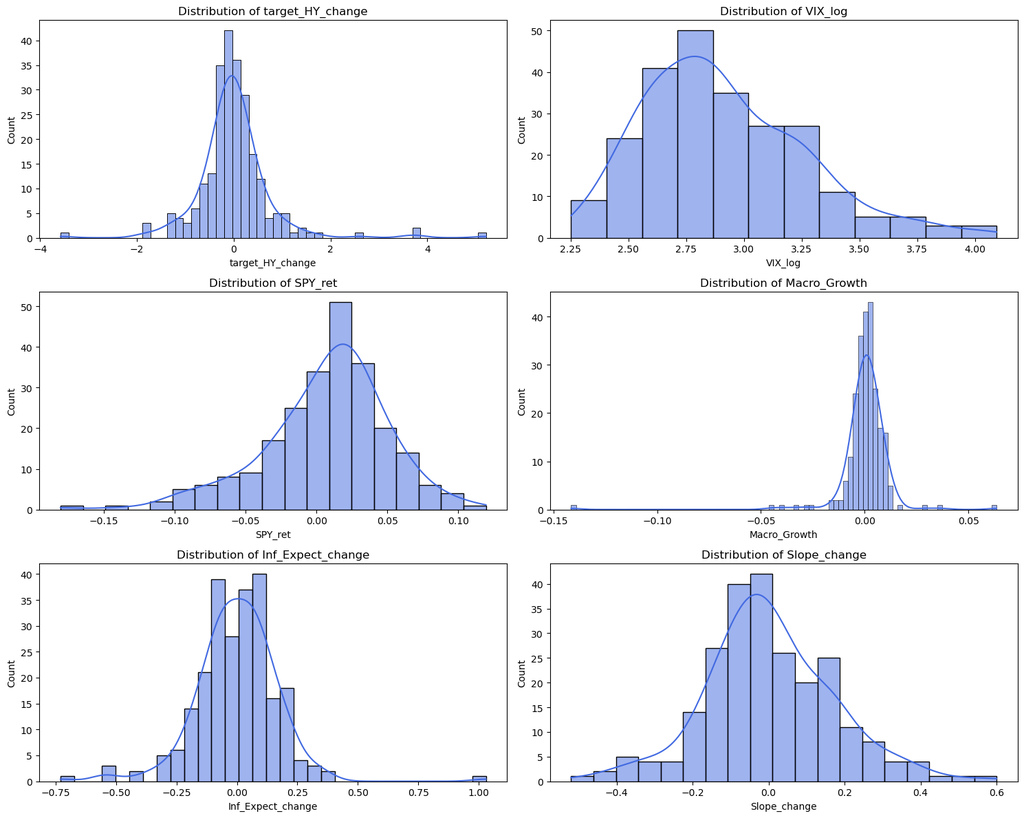

```python
# 1. Use the EXACT names from your transformed_df
# Note: Ensure you use 'target_HY_change' and other new names
cols_to_plot = [
    'target_HY_change',
    'VIX_log',
    'SPY_ret',
    'Macro_Growth',
    'Inf_Expect_change',
    'Slope_change'
]

# 2. Create the plots
plt.figure(figsize=(15, 12))

for i, col in enumerate(cols_to_plot, 1):
    plt.subplot(3, 2, i)

    # Verify the column exists to avoid a KeyError
    if col in transformed_df.columns:
        sns.histplot(transformed_df[col], kde=True, color='royalblue')
        plt.title(f'Distribution of {col}')
    else:
        print(f"Warning: {col} not found in transformed_df")

plt.tight_layout()
plt.show()
```

## 7. LASSO Regression (Monthly)

**Why LASSO?** With 7 macro features and a relatively small monthly dataset, LASSO's L1 regularisation is well-suited: it performs automatic feature selection by shrinking irrelevant coefficients to zero, reducing overfitting risk.

**Train-test split:** We use a strict chronological 80/20 split — no shuffling. Shuffling time series data would constitute look-ahead bias, artificially inflating test performance.

## Lasso Model (Monthly)

```python
# 1. Define Features (X) and Target (y)
features = [
    'SPY_ret', 'Macro_Growth', 'VIX_log',
    'Slope_change', 'Inf_Expect_change',
    'Rate_change', 'FinCond_change'
]

X = transformed_df[features]
y = transformed_df['target_HY_change']

# 2. Chronological Train-Test Split (80/20)
split_idx = int(len(X) * 0.8)

X_train, X_test = X.iloc[:split_idx], X.iloc[split_idx:]
y_train, y_test = y.iloc[:split_idx], y.iloc[split_idx:]

print(f"Training set size: {len(X_train)}")
print(f"Testing set size:  {len(X_test)}")

# 3. Create the LASSO Pipeline
lasso_pipe = Pipeline([
    ('scaler', StandardScaler()),
    ('lasso', Lasso(max_iter=10000)) # Increased max_iter for convergence
])

# 4. Hyperparameter Tuning using GridSearchCV
param_grid = {'lasso__alpha': np.logspace(-4, 1, 50)}

grid_search = GridSearchCV(
    lasso_pipe,
    param_grid,
    cv=5,
    scoring='neg_mean_squared_error' # Using MSE as per your Evaluation slide
)

grid_search.fit(X_train, y_train)

# 5. Evaluate the Model (Step 4: Evaluation)
best_lasso = grid_search.best_estimator_
y_pred = best_lasso.predict(X_test)

# RMSE Calculation
rmse = np.sqrt(mean_squared_error(y_test, y_pred))

print(f"\nBest Alpha: {grid_search.best_params_['lasso__alpha']:.4f}")
print(f"Test RMSE: {rmse:.4f}")

# 6. Feature Importance (Coefficients)
coefs = pd.Series(
    best_lasso.named_steps['lasso'].coef_,
    index=features
).sort_values(ascending=False)

print("\nLASSO Coefficients:")
print(coefs)
```

```
Training set size: 192
Testing set size:  48

Best Alpha: 0.0569
Test RMSE: 0.2349

LASSO Coefficients:
Macro_Growth        -0.000000
VIX_log              0.000000
Slope_change         0.000000
Rate_change         -0.089423
FinCond_change      -0.214101
Inf_Expect_change   -0.242544
SPY_ret             -0.261207
dtype: float64
```

### LASSO: Train vs Test Performance

Comparing in-sample and out-of-sample RMSE helps diagnose overfitting.

```python
# 1. Predict on both sets
y_train_pred = best_lasso.predict(X_train)
y_test_pred = best_lasso.predict(X_test)

# 2. Calculate RMSE for both
train_rmse = root_mean_squared_error(y_train, y_train_pred)
test_rmse = root_mean_squared_error(y_test, y_test_pred)

print(f"Training RMSE: {train_rmse:.4f}")
print(f"Testing RMSE:  {test_rmse:.4f}")

# 3. Check R-Squared (Lecture 2)
from sklearn.metrics import r2_score
print(f"Training R2:   {r2_score(y_train, y_train_pred):.4f}")
```

```
Training RMSE: 0.4359
Testing RMSE:  0.2349
Training R2:   0.7319
```

### LASSO: Full Evaluation and Prediction Plot

```
--- LASSO Evaluation Metrics ---
MAE:  0.1862
RMSE: 0.2349
R2:   0.6804
```

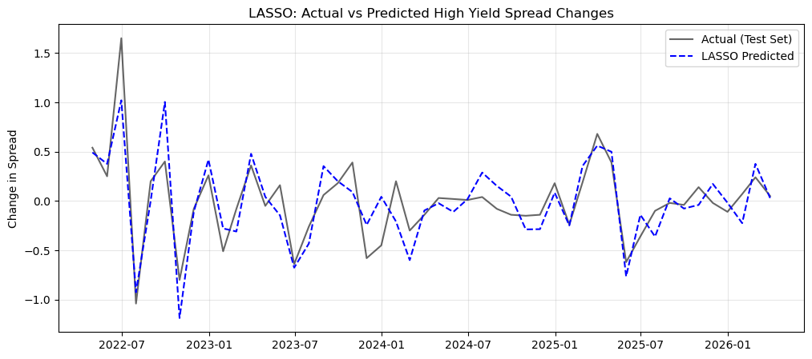

```python
# 1. Generate Predictions using the LASSO Pipeline
y_pred_lasso = best_lasso.predict(X_test)

# 2. Evaluation Metrics
mae_lasso = mean_absolute_error(y_test, y_pred_lasso)
rmse_lasso = np.sqrt(mean_squared_error(y_test, y_pred_lasso))
r2_lasso = r2_score(y_test, y_pred_lasso)

print(f"--- LASSO Evaluation Metrics ---")
print(f"MAE:  {mae_lasso:.4f}")
print(f"RMSE: {rmse_lasso:.4f}")
print(f"R2:   {r2_lasso:.4f}")

# 3. Step 3: Prediction Graph (Time Series)
plt.figure(figsize=(12, 5))
plt.plot(y_test.index, y_test.values, label='Actual (Test Set)', color='black', alpha=0.6)
plt.plot(y_test.index, y_pred_lasso, label='LASSO Predicted', color='blue', linestyle='--')
plt.title('LASSO: Actual vs Predicted High Yield Spread Changes')
plt.ylabel('Change in Spread')
plt.legend()
plt.grid(True, alpha=0.3)
plt.show()
```

## 8. XGBoost (Monthly)

**Why XGBoost?** Unlike LASSO, XGBoost can capture non-linear relationships between macro drivers and spread changes. This is particularly relevant during stress periods (e.g. 2008, 2020) where relationships between variables may be highly non-linear. We tune hyperparameters using cross-validated grid search on the training set only.

## XGBoost (Monthly data)

```python
# 1. Define Features and Target (Using your stationary transformed variables)
features = [
    'SPY_ret', 'Macro_Growth', 'VIX_log',
    'Slope_change', 'Inf_Expect_change',
    'Rate_change', 'FinCond_change'
]

X = transformed_df[features]
y = transformed_df['target_HY_change']

# 2. Chronological Split (No Shuffling for Time Series!)
split_idx = int(len(transformed_df) * 0.8)
X_train, X_test = X.iloc[:split_idx], X.iloc[split_idx:]
y_train, y_test = y.iloc[:split_idx], y.iloc[split_idx:]

# 3. Set up the XGBoost Regressor
# We keep max_depth low (3) because we have a small (monthly) dataset
xgb_reg = xgb.XGBRegressor(objective='reg:squarederror', random_state=42)

# 4. Define Hyperparameter Grid (Lecture 6 Tuning)
# We focus on 'learning_rate' and 'n_estimators' to control the speed of learning
param_grid = {
    'n_estimators': [50, 100, 200],
    'learning_rate': [0.01, 0.05, 0.1],
    'max_depth': [1, 2, 3],
    'subsample': [0.8] # Prevents overfitting by using subsets of data
}

# 5. Grid Search with Cross-Validation
grid_xgb = GridSearchCV(
    estimator=xgb_reg,
    param_grid=param_grid,
    cv=5,
    scoring='neg_mean_squared_error',
    verbose=1
)

grid_xgb.fit(X_train, y_train)

# 6. Evaluate the Best Model
best_xgb = grid_xgb.best_estimator_
y_pred_xgb = best_xgb.predict(X_test)
rmse_xgb = np.sqrt(mean_squared_error(y_test, y_pred_xgb))

print(f"Best XGB Params: {grid_xgb.best_params_}")
print(f"XGBoost Test RMSE: {rmse_xgb:.4f}")
```

```
Fitting 5 folds for each of 27 candidates, totalling 135 fits
Best XGB Params: {'learning_rate': 0.05, 'max_depth': 2, 'n_estimators': 100, 'subsample': 0.8}
XGBoost Test RMSE: 0.2784
```

### Feature Importance

XGBoost's gain-based feature importance reveals which macro drivers contribute most to predicting spread changes.

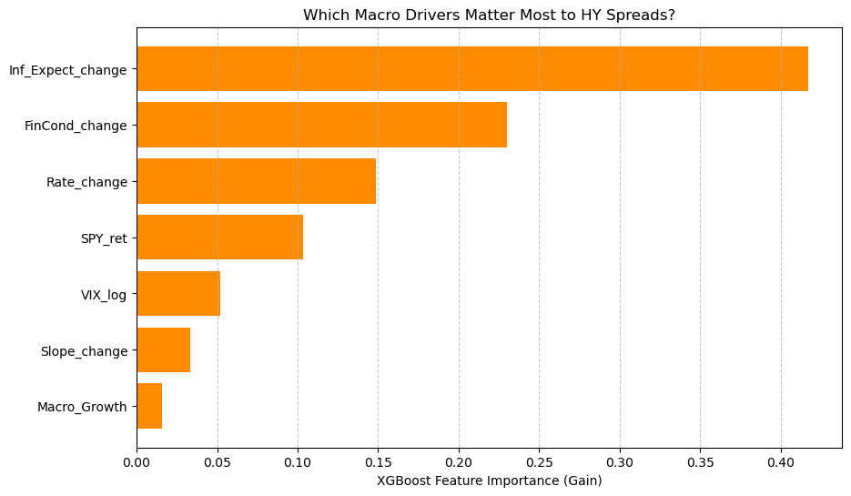

```python
# Get importance scores
importances = best_xgb.feature_importances_
feature_names = X.columns

# Sort them for plotting
sorted_idx = importances.argsort()

plt.figure(figsize=(10, 6))
plt.barh(range(len(sorted_idx)), importances[sorted_idx], align='center', color='darkorange')
plt.yticks(range(len(sorted_idx)), [feature_names[i] for i in sorted_idx])
plt.xlabel('XGBoost Feature Importance (Gain)')
plt.title('Which Macro Drivers Matter Most to HY Spreads?')
plt.grid(axis='x', linestyle='--', alpha=0.7)
plt.show()
```

### XGBoost: Prediction vs Actual (Test Set)

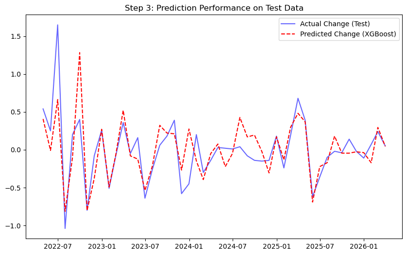

```python
# Generate predictions for the test set
y_pred_xgb = best_xgb.predict(X_test)

plt.figure(figsize=(10, 6))
plt.plot(y_test.index, y_test.values, label='Actual Change (Test)', color='blue', alpha=0.6)
plt.plot(y_test.index, y_pred_xgb, label='Predicted Change (XGBoost)', color='red', linestyle='--')
plt.title('Step 3: Prediction Performance on Test Data')
plt.legend()
plt.show()
```

### XGBoost: Evaluation Metrics

```python
mae = mean_absolute_error(y_test, y_pred_xgb)
rmse = np.sqrt(mean_squared_error(y_test, y_pred_xgb))

print(f"Typical Error (MAE): {mae:.4f}")
print(f"Outlier-Sensitive Error (RMSE): {rmse:.4f}")
```

```
Typical Error (MAE): 0.1856
Outlier-Sensitive Error (RMSE): 0.2784
```

## 9. LASSO and XGBoost on Daily Data

We repeat the full pipeline on daily frequency data. Daily data provides ~20x more observations but introduces higher noise. Industrial Production is excluded as it is only reported monthly. We compare model performance across frequencies to assess whether higher granularity improves predictive accuracy.

# Lasso and XGBoost (Daily data)

```
Daily LASSO Test RMSE:   0.0566
Daily XGBoost Test RMSE: 0.0570
```

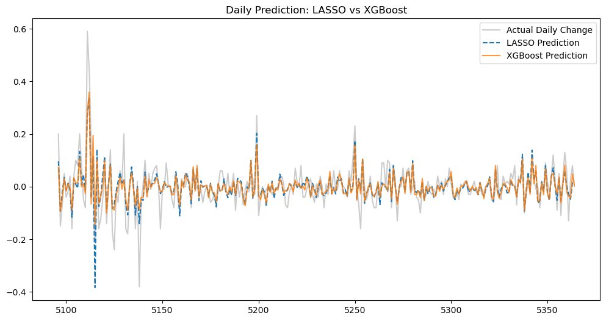

```python
# --- 1. PREPARATION (DAILY DATA) ---
# We drop 'Ind_Pro' as it's monthly, then drop NaNs to align daily dates
daily_df = master_df.drop(columns=['Ind_Pro'], errors='ignore').dropna()

# --- 2. STATIONARITY TRANSFORMATIONS (DAILY) ---
transformed_daily = pd.DataFrame(index=daily_df.index)

# Target: Daily change in High Yield Spread
transformed_daily['target_HY_change'] = daily_df['HY_Spread'].diff()

# Features:
transformed_daily['VIX_log'] = np.log(daily_df['VIX'])
transformed_daily['SPY_ret'] = daily_df['SPY'].pct_change()
transformed_daily['Slope_change'] = daily_df['Yield_Slope'].diff()
transformed_daily['Rate_change'] = daily_df['2Y_Treasury'].diff()
transformed_daily['FinCond_change'] = daily_df['Fin_Cond'].diff()
transformed_daily['Inf_Expect_change'] = daily_df['Inf_Expect'].diff()

# Remove the first row containing NaNs from diff/pct_change
transformed_daily = transformed_daily.dropna()

# --- 3. DEFINE FEATURES & CHRONOLOGICAL SPLIT ---
features_daily = ['VIX_log', 'SPY_ret', 'Slope_change', 'Rate_change', 'FinCond_change', 'Inf_Expect_change']
X_daily = transformed_daily[features_daily]
y_daily = transformed_daily['target_HY_change']

# 80/20 Chronological Split
split_idx_daily = int(len(X_daily) * 0.95)
X_train_daily, X_test_daily = X_daily.iloc[:split_idx_daily], X_daily.iloc[split_idx_daily:]
y_train_daily, y_test_daily = y_daily.iloc[:split_idx_daily], y_daily.iloc[split_idx_daily:]

# --- 4. MODEL 1: LASSO (DAILY) ---
lasso_pipe_daily = Pipeline([
    ('scaler', StandardScaler()),
    ('lasso', Lasso(max_iter=10000))
])
param_grid_lasso_daily = {'lasso__alpha': np.logspace(-5, 0, 50)}
grid_lasso_daily = GridSearchCV(lasso_pipe_daily, param_grid_lasso_daily, cv=5, scoring='neg_root_mean_squared_error')
grid_lasso_daily.fit(X_train_daily, y_train_daily)

best_lasso_daily = grid_lasso_daily.best_estimator_
y_pred_lasso_daily = best_lasso_daily.predict(X_test_daily)
rmse_lasso_daily = np.sqrt(mean_squared_error(y_test_daily, y_pred_lasso_daily))

# --- 5. MODEL 2: XGBOOST (DAILY) ---
param_grid_xgb_daily = {
    'learning_rate': [0.01, 0.05, 0.1],
    'max_depth': [2, 3, 4],
    'n_estimators': [100, 200],
    'subsample': [0.8]
}
xgb_model_daily = xgb.XGBRegressor(objective='reg:squarederror', random_state=42)
grid_xgb_daily = GridSearchCV(xgb_model_daily, param_grid_xgb_daily, cv=5, scoring='neg_root_mean_squared_error')
grid_xgb_daily.fit(X_train_daily, y_train_daily)

best_xgb_daily = grid_xgb_daily.best_estimator_
y_pred_xgb_daily = best_xgb_daily.predict(X_test_daily)
rmse_xgb_daily = np.sqrt(mean_squared_error(y_test_daily, y_pred_xgb_daily))

# --- 6. FINAL COMPARISON ---
print(f"Daily LASSO Test RMSE:   {rmse_lasso_daily:.4f}")
print(f"Daily XGBoost Test RMSE: {rmse_xgb_daily:.4f}")

# Plotting the result
plt.figure(figsize=(12, 6))
plt.plot(y_test_daily.index, y_test_daily.values, label='Actual Daily Change', alpha=0.4, color='gray')
plt.plot(y_test_daily.index, y_pred_lasso_daily, label='LASSO Prediction', linestyle='--')
plt.plot(y_test_daily.index, y_pred_xgb_daily, label='XGBoost Prediction', alpha=0.8)
plt.title('Daily Prediction: LASSO vs XGBoost')
plt.legend()
plt.show()
```

### Daily Models: Predictions and RMSE Comparison

```python
# --- 1. Generate Predictions for Train and Test Sets ---

# LASSO Predictions
y_train_pred_lasso = best_lasso_daily.predict(X_train_daily)
y_test_pred_lasso = best_lasso_daily.predict(X_test_daily)

# XGBoost Predictions
y_train_pred_xgb = best_xgb_daily.predict(X_train_daily)
y_test_pred_xgb = best_xgb_daily.predict(X_test_daily)

# --- 2. Calculate Train and Test RMSE ---

# LASSO RMSE
train_rmse_lasso = np.sqrt(mean_squared_error(y_train_daily, y_train_pred_lasso))
test_rmse_lasso = np.sqrt(mean_squared_error(y_test_daily, y_test_pred_lasso))

# XGBoost RMSE
train_rmse_xgb = np.sqrt(mean_squared_error(y_train_daily, y_train_pred_xgb))
test_rmse_xgb = np.sqrt(mean_squared_error(y_test_daily, y_test_pred_xgb))

# --- 3. Calculate MAE and R^2 (Test Set) ---

# R-squared
r2_lasso = r2_score(y_test_daily, y_test_pred_lasso)
r2_xgb = r2_score(y_test_daily, y_test_pred_xgb)

# MAE
mae_lasso = mean_absolute_error(y_test_daily, y_test_pred_lasso)
mae_xgb = mean_absolute_error(y_test_daily, y_test_pred_xgb)

# --- 4. Print Overall Model Performance ---
print("--- Daily LASSO Performance ---")
print(f"Train RMSE: {train_rmse_lasso:.4f}")
print(f"Test RMSE:  {test_rmse_lasso:.4f}")
print(f"Test MAE:   {mae_lasso:.4f}")
print(f"Test R^2:   {r2_lasso:.4f}\n")

print("--- Daily XGBoost Performance ---")
print(f"Train RMSE: {train_rmse_xgb:.4f}")
print(f"Test RMSE:  {test_rmse_xgb:.4f}")
print(f"Test MAE:   {mae_xgb:.4f}")
print(f"Test R^2:   {r2_xgb:.4f}\n")
print("-" * 40, "\n")

# --- 5. Extract Coefficients and Feature Importances ---

# LASSO Coefficients (Linear Impact)
lasso_coefs = pd.Series(
    best_lasso_daily.named_steps['lasso'].coef_,
    index=features_daily
).sort_values(ascending=False)

print("--- LASSO Coefficients (Directional Impact) ---")
print(lasso_coefs)
print("\n")

# XGBoost Feature Importances (Relative Weight)
xgb_importances = pd.Series(
    best_xgb_daily.feature_importances_,
    index=features_daily
).sort_values(ascending=False)

print("--- XGBoost Feature Importances (Predictive Weight) ---")
print(xgb_importances)
```

```
--- Daily LASSO Performance ---
Train RMSE: 0.0812
Test RMSE:  0.0566
Test MAE:   0.0396
Test R^2:   0.5593

--- Daily XGBoost Performance ---
Train RMSE: 0.0766
Test RMSE:  0.0570
Test MAE:   0.0389
Test R^2:   0.5523

----------------------------------------

--- LASSO Coefficients (Directional Impact) ---
VIX_log              0.007239
Slope_change        -0.009706
SPY_ret             -0.014146
Inf_Expect_change   -0.021381
Rate_change         -0.022352
FinCond_change      -0.032148
dtype: float64


--- XGBoost Feature Importances (Predictive Weight) ---
FinCond_change       0.453358
Rate_change          0.130063
Inf_Expect_change    0.130061
VIX_log              0.119174
SPY_ret              0.118203
Slope_change         0.049142
dtype: float32
```

```python
from sklearn.metrics import mean_absolute_error

# 1. Calculate MAE for both models
mae_lasso = mean_absolute_error(y_test, y_pred_lasso)
mae_xgb = mean_absolute_error(y_test, y_pred_xgb)

print(f"--- Daily Prediction Accuracy (MAE) ---")
print(f"LASSO MAE:   {mae_lasso:.4f}")
print(f"XGBoost MAE: {mae_xgb:.4f}")
```

[output not shown]

## 10. Residual Analysis

Well-specified models should produce residuals that are approximately normally distributed and centred around zero. Systematic patterns in residuals would suggest the model is missing structure in the data (e.g. autocorrelation, regime changes).

## Evaluating the models using residual plots

```python
def plot_residual_distributions(y_actual, y_pred_lasso, y_pred_xgb, frequency_label="Daily"):
    # Calculate residuals
    res_lasso = y_actual - y_pred_lasso
    res_xgb = y_actual - y_pred_xgb

    plt.figure(figsize=(12, 5))

    # LASSO Residuals
    plt.subplot(1, 2, 1)
    sns.histplot(res_lasso, kde=True, color='blue', bins=50)
    plt.axvline(0, color='red', linestyle='--', linewidth=2)
    plt.title(f'LASSO Residuals ({frequency_label})')
    plt.xlabel('Error (Actual - Predicted)')
    plt.ylabel('Frequency')

    # XGBoost Residuals
    plt.subplot(1, 2, 2)
    sns.histplot(res_xgb, kde=True, color='green', bins=50)
    plt.axvline(0, color='red', linestyle='--', linewidth=2)
    plt.title(f'XGBoost Residuals ({frequency_label})')
    plt.xlabel('Error (Actual - Predicted)')
    plt.ylabel('Frequency')

    plt.tight_layout()
    plt.show()
```

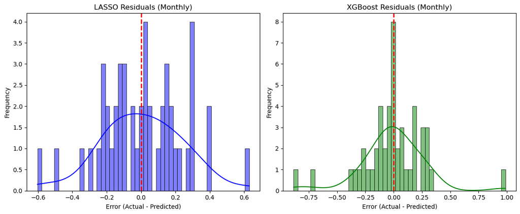

```python
# Plot residual distributions for the Monthly models
plot_residual_distributions(y_test, y_pred_lasso, y_pred_xgb, "Monthly")
```

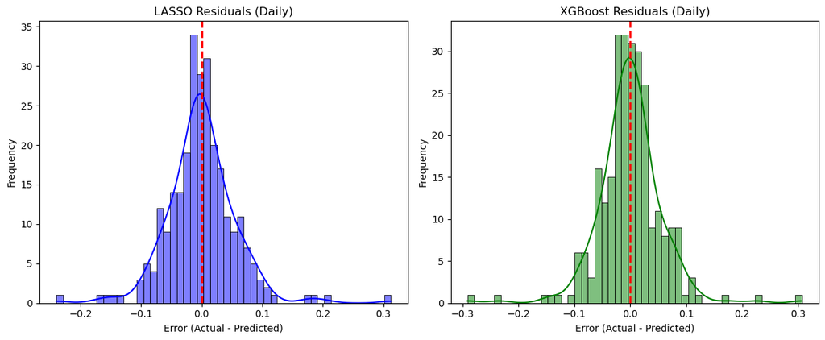

```python
# Plot residual distributions for the Daily models
plot_residual_distributions(y_test_daily, y_pred_lasso_daily, y_pred_xgb_daily, "Daily")
```